# Anxiety-like Behavior: Multilevel Meta-analysis

2025-12-14

# Purpose and scope

This report presents a multilevel meta-analysis of anxiety-like behavior across experimental categories. For each category, effects are synthesised using a multilevel REML model with random effects at the study and experiment levels.

# Results by category

## Category: Pro-dopaminergic agents

### Overall effect

```
Multivariate Meta-Analysis Model (k = 18; method: REML)

Variance Components:

            estim    sqrt  nlvls  fixed           factor
sigma^2.1  0.0564  0.2374      6     no         study_id
sigma^2.2  0.0000  0.0001      7     no  study_id/exp_id

Test for Heterogeneity:
Q(df = 17) = 79.6051, p-val < .0001

Number of estimates:   18
Number of clusters:    6
Estimates per cluster: 1-6 (mean: 3.00, median: 3)

Model Results:

estimate      se¹     tval¹  df¹    pval¹    ci.lb¹   ci.ub¹
 -0.1073  0.1706   -0.6287    5   0.5572   -0.5459   0.3314

---
Signif. codes:  0 '***' 0.001 '**' 0.01 '*' 0.05 '.' 0.1 ' ' 1

1) results based on cluster-robust inference (var-cov estimator: CR1,
   approx t-test and confidence interval, df: residual method)
```

| category | estimate | ci_lb | ci_ub | p_value | sigma2_between | sigma2_within | k | n_studies |
| --- | --- | --- | --- | --- | --- | --- | --- | --- |
| Pro-dopaminergic agents | -0.1073 | -0.5459 | 0.3314 | 0.5572 | 0.0564 | 0 | 18 | 6 |

### Forest plot

**Caption.** Forest plot of individual effect sizes and the pooled multilevel estimate, including a prediction interval. **Interpretation.** The pooled summary represents the average effect; the prediction interval reflects the expected range of true effects in new studies given heterogeneity.

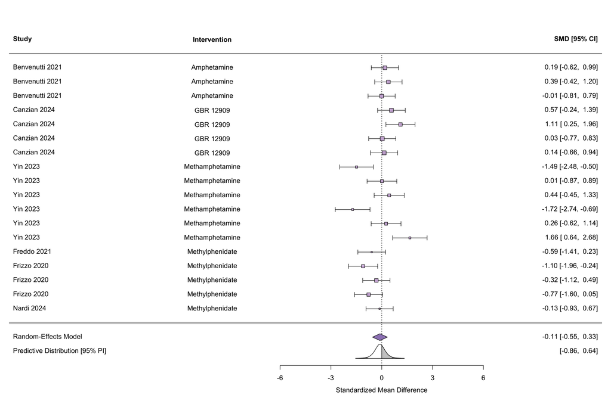

### Heterogeneity and variance decomposition

| category | I2_total | I2_between | I2_within |
| --- | --- | --- | --- |
| Pro-dopaminergic agents | 22.973 | 22.973 | 0 |

**Interpretation.** I² quantifies the proportion of variability attributable to heterogeneity rather than sampling error, decomposed into between- and within-study components.

### Distribution of effects (orchard plot)

**Caption.** Orchard plot for the multilevel model for this category (PNG saved by the pipeline; colour scheme matches the original script). **Interpretation.** Orchard plots complement forest plots by visualising the distribution of effects with multilevel uncertainty and heterogeneity.

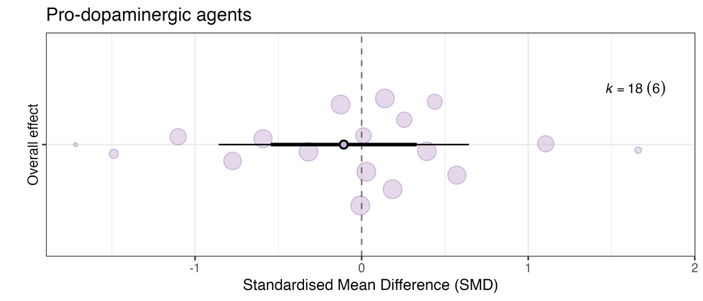

### Small-study effects and publication bias

#### Egger-type regressions

| category | slope_SE | p_SE | slope_SEeff | p_SEeff |
| --- | --- | --- | --- | --- |
| Pro-dopaminergic agents | -7.4336 | 0.06 | 3.3665 | 0.7897 |

**Interpretation.** The slope tests whether effect sizes are associated with sampling error (SE) or effective SE. Consistent significance may indicate small-study effects.

#### Funnel plot (Sampling Error)

**Caption.** Funnel plot using Sampling Error. **Interpretation.** Symmetry suggests little evidence of small-study effects; asymmetry suggests potential dissemination bias or related mechanisms.

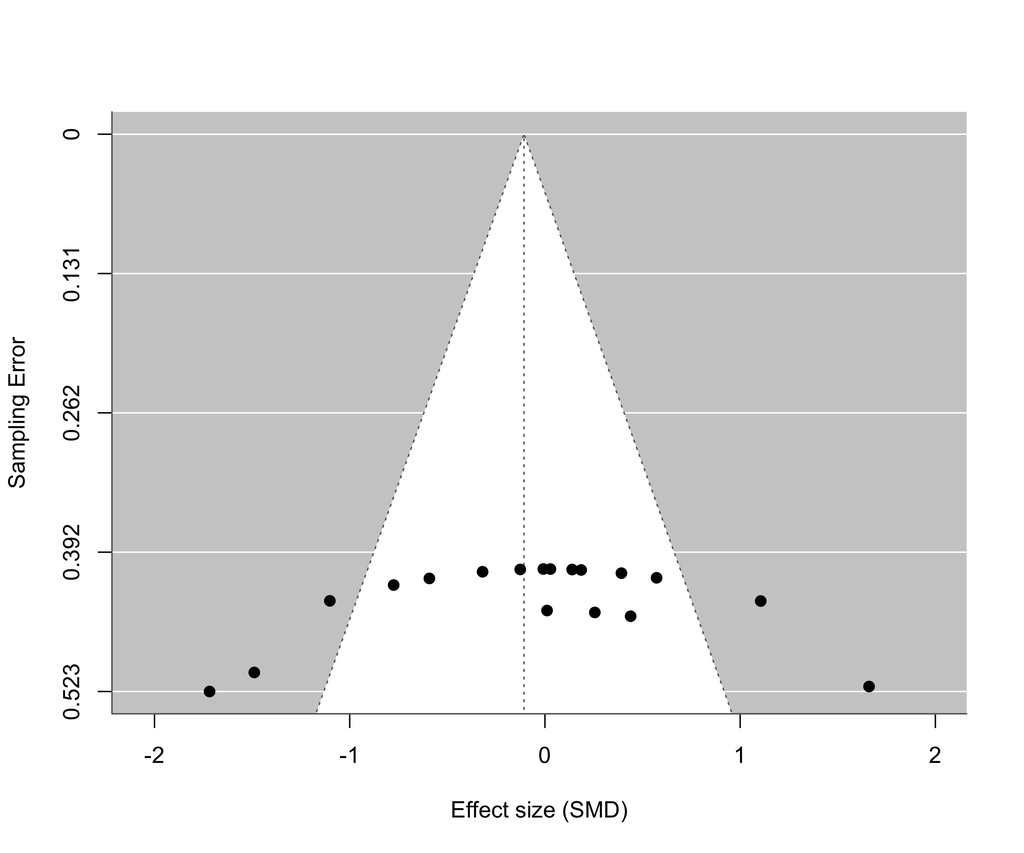

#### Funnel plot (precision = 1/√n)

**Caption.** Funnel plot using 1/√n as an alternative measure of precision. **Interpretation.** Agreement between the two funnel diagnostics strengthens inference about small-study effects.

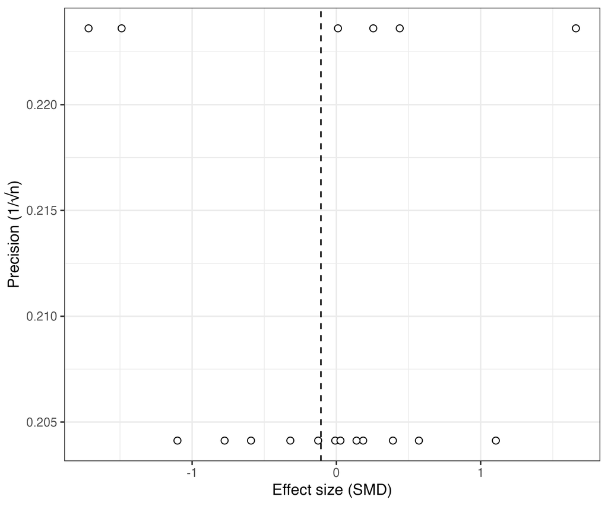

#### Bubble plot (Egger regression)

**Caption.** Bubble plot of effect sizes versus sampling error (SE), with study clustering. **Interpretation.** A visually non-zero slope is consistent with Egger regression evidence for small-study effects; a near-zero slope supports their absence.

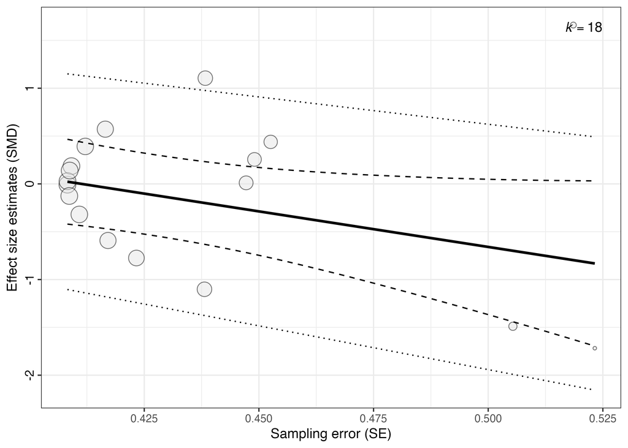

### Sensitivity analyses

#### 5.1 Leave-one-study-out

This analysis repeats the meta-analysis while removing one study at a time to assess influence. **Interpretation.** Large shifts in the pooled estimate indicate influential studies; stability indicates robustness.

| category | left_out | estimate | ci_lb | ci_ub | p_value | sigma2_between | sigma2_within | k | n_studies |
| --- | --- | --- | --- | --- | --- | --- | --- | --- | --- |
| Pro-dopaminergic agents | Benvenutti_2021 | -0.1735 | -0.7288 | 0.3818 | 0.4346 | 0.0795 | 0.0000 | 15 | 5 |
| Pro-dopaminergic agents | Canzian_2024 | -0.2083 | -0.6792 | 0.2625 | 0.2867 | 0.0258 | 0.0000 | 14 | 5 |
| Pro-dopaminergic agents | Yin_2023 | -0.1417 | -0.7527 | 0.4693 | 0.5547 | 0.0549 | 0.0549 | 12 | 5 |
| Pro-dopaminergic agents | Freddo_2021 | -0.0359 | -0.5302 | 0.4583 | 0.8499 | 0.0482 | 0.0000 | 17 | 5 |
| Pro-dopaminergic agents | Frizzo_2020 | 0.0227 | -0.3529 | 0.3984 | 0.8747 | 0.0000 | 0.0000 | 15 | 5 |
| Pro-dopaminergic agents | Nardi_2024 | -0.1105 | -0.6748 | 0.4537 | 0.6154 | 0.0942 | 0.0000 | 17 | 5 |

#### Sensitivity to within-study correlation (rho)

This analysis varies the assumed within-study correlation among effect sizes. **Interpretation.** Stability of pooled estimates across rho values indicates robustness to assumptions about within-study dependence.

| category | rho | estimate | ci_lb | ci_ub | p_value | sigma2_between | sigma2_within | k | n_studies |
| --- | --- | --- | --- | --- | --- | --- | --- | --- | --- |
| Pro-dopaminergic agents | 0.0 | -0.1108 | -0.5975 | 0.3760 | 0.5840 | 0.1396 | 3e-04 | 18 | 6 |
| Pro-dopaminergic agents | 0.2 | -0.1116 | -0.5820 | 0.3589 | 0.5687 | 0.1078 | 0e+00 | 18 | 6 |
| Pro-dopaminergic agents | 0.4 | -0.1100 | -0.5604 | 0.3404 | 0.5577 | 0.0740 | 0e+00 | 18 | 6 |
| Pro-dopaminergic agents | 0.5 | -0.1073 | -0.5459 | 0.3314 | 0.5572 | 0.0564 | 0e+00 | 18 | 6 |
| Pro-dopaminergic agents | 0.6 | -0.1019 | -0.5278 | 0.3240 | 0.5654 | 0.0385 | 0e+00 | 18 | 6 |
| Pro-dopaminergic agents | 0.8 | -0.0704 | -0.4879 | 0.3472 | 0.6830 | 0.0174 | 0e+00 | 18 | 6 |

## Category: Estradiol and alike

### Overall effect

```
Multivariate Meta-Analysis Model (k = 27; method: REML)

Variance Components:

            estim    sqrt  nlvls  fixed           factor
sigma^2.1  0.0000  0.0001      6     no         study_id
sigma^2.2  0.0576  0.2400      8     no  study_id/exp_id

Test for Heterogeneity:
Q(df = 26) = 306.5704, p-val < .0001

Number of estimates:   27
Number of clusters:    6
Estimates per cluster: 1-10 (mean: 4.50, median: 2.5)

Model Results:

estimate      se¹     tval¹  df¹    pval¹    ci.lb¹   ci.ub¹
 -0.2749  0.1098   -2.5031    5   0.0543   -0.5572   0.0074   .

---
Signif. codes:  0 '***' 0.001 '**' 0.01 '*' 0.05 '.' 0.1 ' ' 1

1) results based on cluster-robust inference (var-cov estimator: CR1,
   approx t-test and confidence interval, df: residual method)
```

| category | estimate | ci_lb | ci_ub | p_value | sigma2_between | sigma2_within | k | n_studies |
| --- | --- | --- | --- | --- | --- | --- | --- | --- |
| Estradiol and alike | -0.2749 | -0.5572 | 0.0074 | 0.0543 | 0 | 0.0576 | 27 | 6 |

### Forest plot

**Caption.** Forest plot of individual effect sizes and the pooled multilevel estimate, including a prediction interval. **Interpretation.** The pooled summary represents the average effect; the prediction interval reflects the expected range of true effects in new studies given heterogeneity.

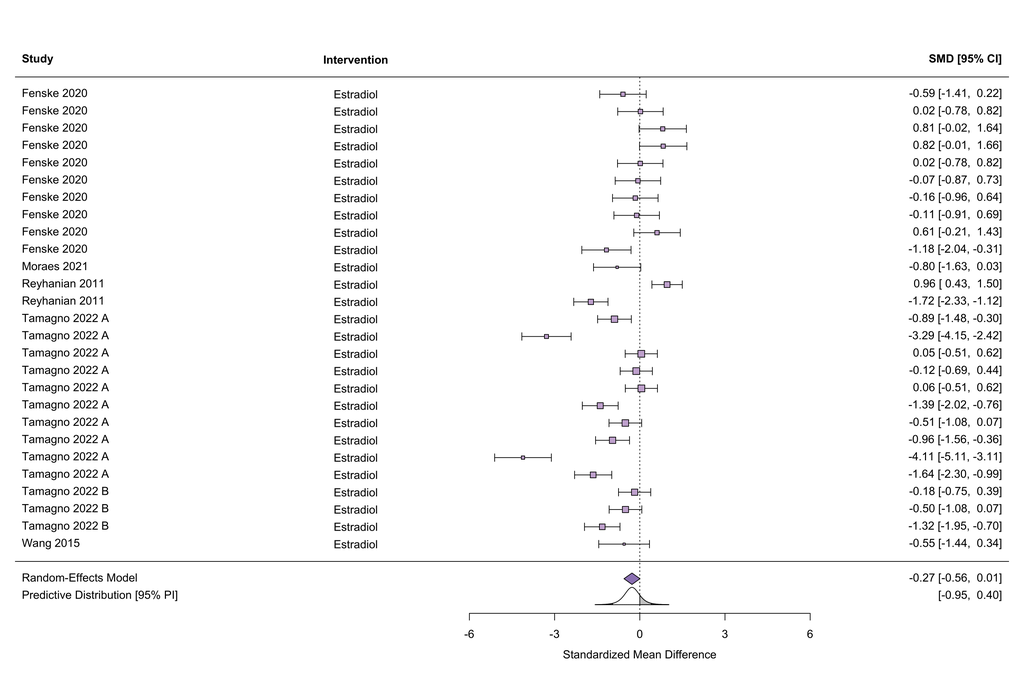

### Heterogeneity and variance decomposition

| category | I2_total | I2_between | I2_within |
| --- | --- | --- | --- |
| Estradiol and alike | 32.053 | 0 | 32.053 |

**Interpretation.** I² quantifies the proportion of variability attributable to heterogeneity rather than sampling error, decomposed into between- and within-study components.

### Distribution of effects (orchard plot)

**Caption.** Orchard plot for the multilevel model for this category (PNG saved by the pipeline; colour scheme matches the original script). **Interpretation.** Orchard plots complement forest plots by visualising the distribution of effects with multilevel uncertainty and heterogeneity.

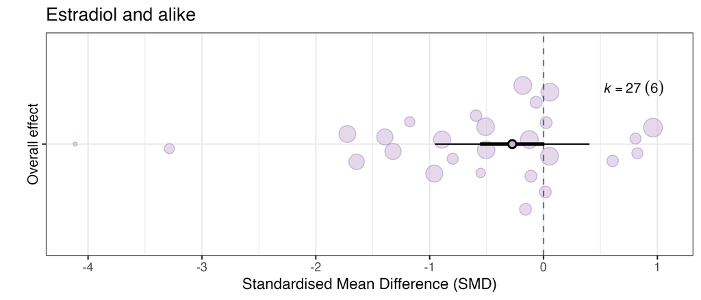

### Small-study effects and publication bias

#### Egger-type regressions

| category | slope_SE | p_SE | slope_SEeff | p_SEeff |
| --- | --- | --- | --- | --- |
| Estradiol and alike | -19.7227 | 0 | -0.8252 | 0.7103 |

**Interpretation.** The slope tests whether effect sizes are associated with sampling error (SE) or effective SE. Consistent significance may indicate small-study effects.

#### Funnel plot (Sampling Error)

**Caption.** Funnel plot using Sampling Error. **Interpretation.** Symmetry suggests little evidence of small-study effects; asymmetry suggests potential dissemination bias or related mechanisms.

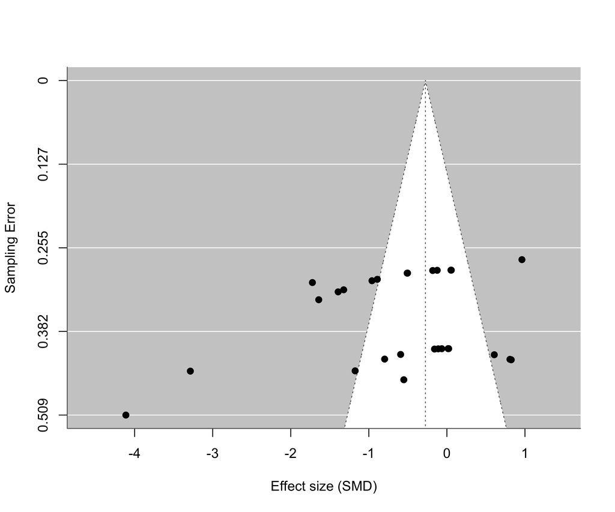

#### Funnel plot (precision = 1/√n)

**Caption.** Funnel plot using 1/√n as an alternative measure of precision. **Interpretation.** Agreement between the two funnel diagnostics strengthens inference about small-study effects.

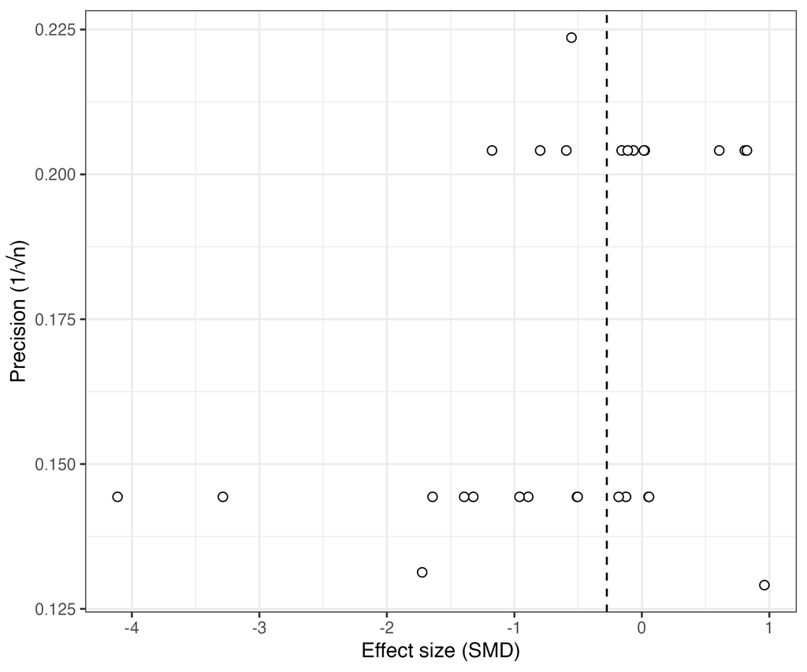

#### Bubble plot (Egger regression)

**Caption.** Bubble plot of effect sizes versus sampling error (SE), with study clustering. **Interpretation.** A visually non-zero slope is consistent with Egger regression evidence for small-study effects; a near-zero slope supports their absence.

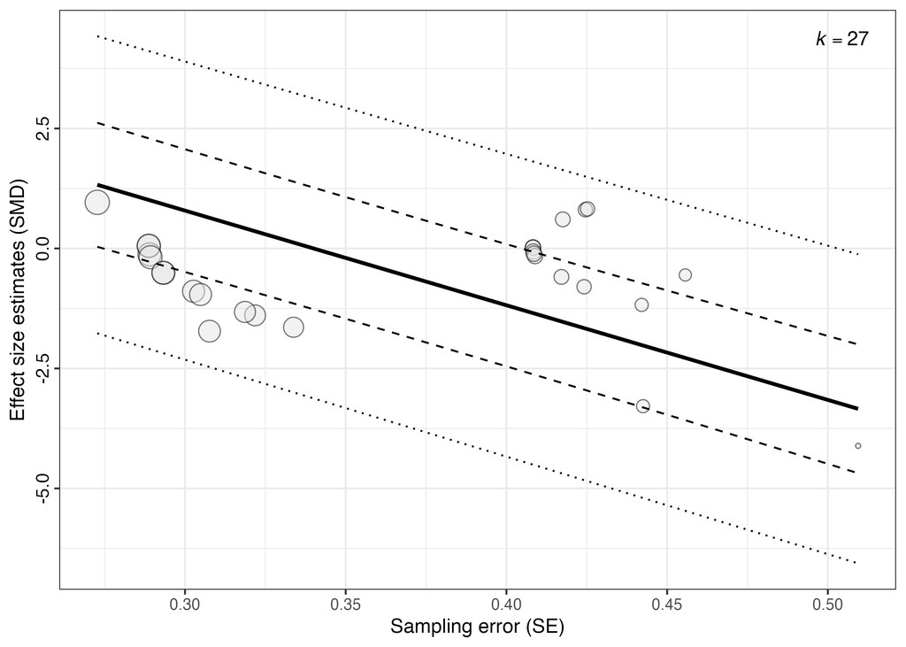

### Sensitivity analyses

#### 5.1 Leave-one-study-out

This analysis repeats the meta-analysis while removing one study at a time to assess influence. **Interpretation.** Large shifts in the pooled estimate indicate influential studies; stability indicates robustness.

| category | left_out | estimate | ci_lb | ci_ub | p_value | sigma2_between | sigma2_within | k | n_studies |
| --- | --- | --- | --- | --- | --- | --- | --- | --- | --- |
| Estradiol and alike | Fenske_2020 | -0.3686 | -0.6657 | -0.0714 | 0.0262 | 0.0000 | 0.0689 | 17 | 5 |
| Estradiol and alike | Moraes_2021 | -0.2316 | -0.5262 | 0.0629 | 0.0944 | 0.0000 | 0.0548 | 26 | 5 |
| Estradiol and alike | Reyhanian_2011 | -0.3147 | -0.6798 | 0.0504 | 0.0749 | 0.0000 | 0.0727 | 25 | 5 |
| Estradiol and alike | Tamagno_2022_A | -0.3042 | -0.7542 | 0.1457 | 0.1337 | 0.0475 | 0.0000 | 17 | 5 |
| Estradiol and alike | Tamagno_2022_B | -0.2202 | -0.5186 | 0.0782 | 0.1099 | 0.0000 | 0.0569 | 24 | 5 |
| Estradiol and alike | Wang_2015 | -0.2549 | -0.5792 | 0.0694 | 0.0945 | 0.0000 | 0.0653 | 26 | 5 |

#### Sensitivity to within-study correlation (rho)

This analysis varies the assumed within-study correlation among effect sizes. **Interpretation.** Stability of pooled estimates across rho values indicates robustness to assumptions about within-study dependence.

| category | rho | estimate | ci_lb | ci_ub | p_value | sigma2_between | sigma2_within | k | n_studies |
| --- | --- | --- | --- | --- | --- | --- | --- | --- | --- |
| Estradiol and alike | 0.0 | -0.4928 | -0.9855 | -0.0001 | 0.0500 | 0.0741 | 0.1300 | 27 | 6 |
| Estradiol and alike | 0.2 | -0.4394 | -0.8678 | -0.0110 | 0.0462 | 0.0354 | 0.1042 | 27 | 6 |
| Estradiol and alike | 0.4 | -0.3467 | -0.6744 | -0.0190 | 0.0418 | 0.0000 | 0.0739 | 27 | 6 |
| Estradiol and alike | 0.5 | -0.2749 | -0.5572 | 0.0074 | 0.0543 | 0.0000 | 0.0576 | 27 | 6 |
| Estradiol and alike | 0.6 | -0.1764 | -0.4979 | 0.1452 | 0.2176 | 0.0000 | 0.0706 | 27 | 6 |
| Estradiol and alike | 0.8 | 0.0441 | -0.7024 | 0.7905 | 0.8853 | 0.3226 | 0.1112 | 27 | 6 |

## Category: Ethanol

### Overall effect

```
Multivariate Meta-Analysis Model (k = 28; method: REML)

Variance Components:

            estim    sqrt  nlvls  fixed           factor
sigma^2.1  0.0000  0.0001      6     no         study_id
sigma^2.2  3.3119  1.8199     11     no  study_id/exp_id

Test for Heterogeneity:
Q(df = 27) = 148.6058, p-val < .0001

Number of estimates:   28
Number of clusters:    6
Estimates per cluster: 1-12 (mean: 4.67, median: 4)

Model Results:

estimate      se¹     tval¹  df¹    pval¹    ci.lb¹   ci.ub¹
 -0.1644  0.4640   -0.3543    5   0.7376   -1.3572   1.0285

---
Signif. codes:  0 '***' 0.001 '**' 0.01 '*' 0.05 '.' 0.1 ' ' 1

1) results based on cluster-robust inference (var-cov estimator: CR1,
   approx t-test and confidence interval, df: residual method)
```

| category | estimate | ci_lb | ci_ub | p_value | sigma2_between | sigma2_within | k | n_studies |
| --- | --- | --- | --- | --- | --- | --- | --- | --- |
| Ethanol | -0.1644 | -1.3572 | 1.0285 | 0.7376 | 0 | 3.3119 | 28 | 6 |

### Forest plot

**Caption.** Forest plot of individual effect sizes and the pooled multilevel estimate, including a prediction interval. **Interpretation.** The pooled summary represents the average effect; the prediction interval reflects the expected range of true effects in new studies given heterogeneity.

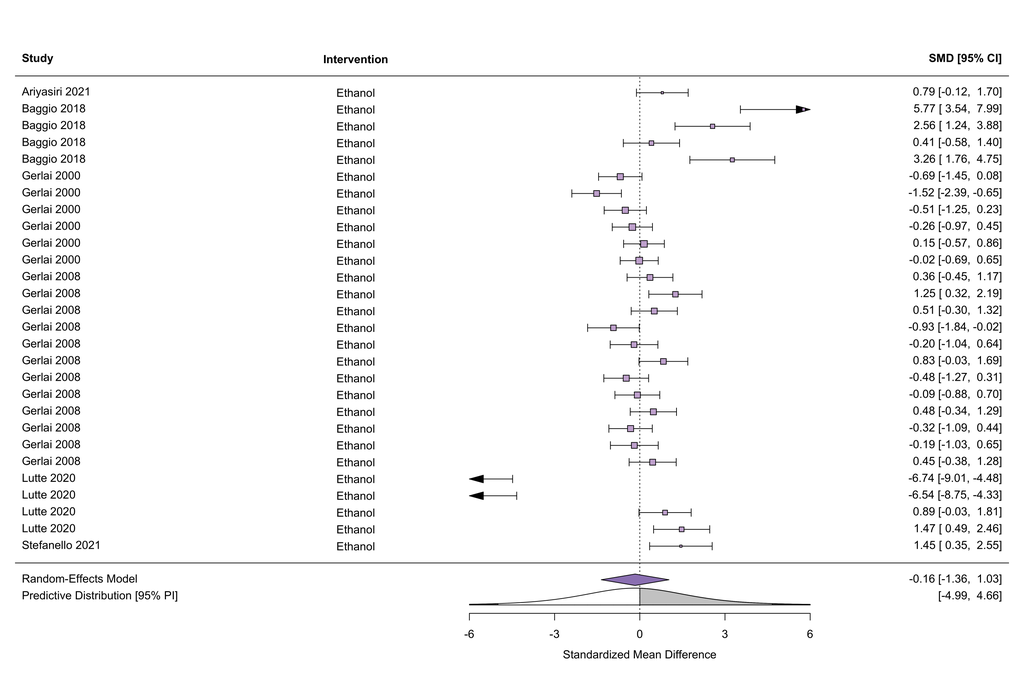

### Heterogeneity and variance decomposition

| category | I2_total | I2_between | I2_within |
| --- | --- | --- | --- |
| Ethanol | 94.105 | 0 | 94.105 |

**Interpretation.** I² quantifies the proportion of variability attributable to heterogeneity rather than sampling error, decomposed into between- and within-study components.

### Distribution of effects (orchard plot)

**Caption.** Orchard plot for the multilevel model for this category (PNG saved by the pipeline; colour scheme matches the original script). **Interpretation.** Orchard plots complement forest plots by visualising the distribution of effects with multilevel uncertainty and heterogeneity.

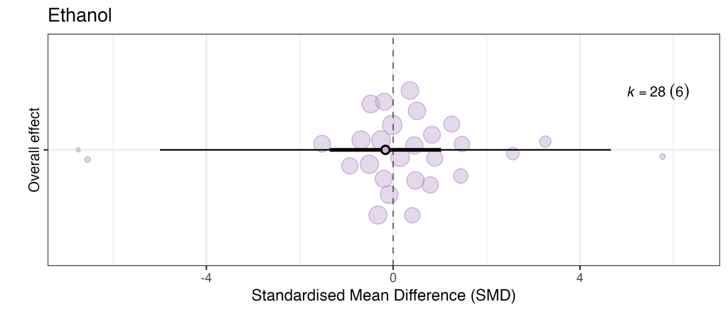

### Small-study effects and publication bias

#### Egger-type regressions

| category | slope_SE | p_SE | slope_SEeff | p_SEeff |
| --- | --- | --- | --- | --- |
| Ethanol | 6.4367 | 0 | 2.6021 | 0.6463 |

**Interpretation.** The slope tests whether effect sizes are associated with sampling error (SE) or effective SE. Consistent significance may indicate small-study effects.

#### Funnel plot (Sampling Error)

**Caption.** Funnel plot using Sampling Error. **Interpretation.** Symmetry suggests little evidence of small-study effects; asymmetry suggests potential dissemination bias or related mechanisms.

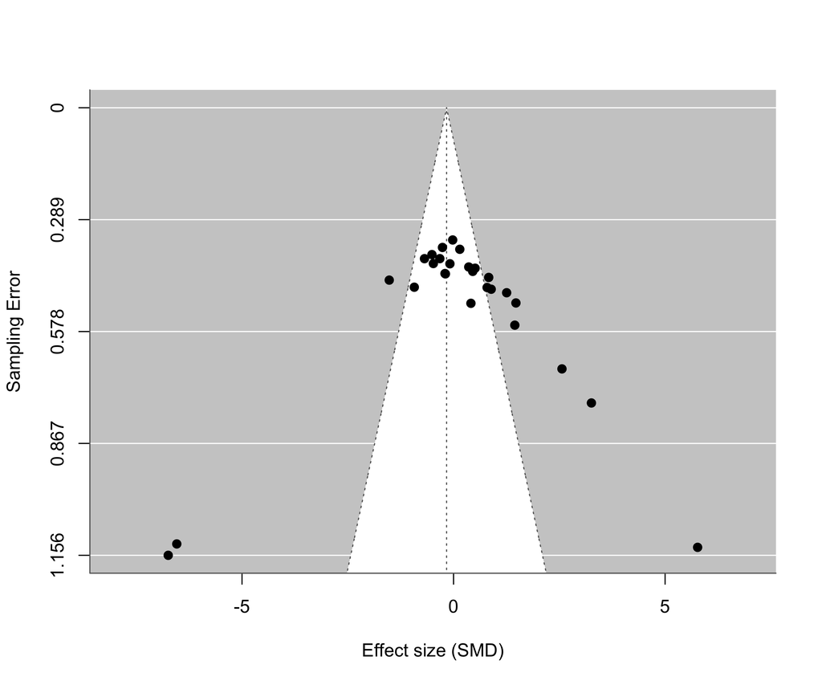

#### Funnel plot (precision = 1/√n)

**Caption.** Funnel plot using 1/√n as an alternative measure of precision. **Interpretation.** Agreement between the two funnel diagnostics strengthens inference about small-study effects.

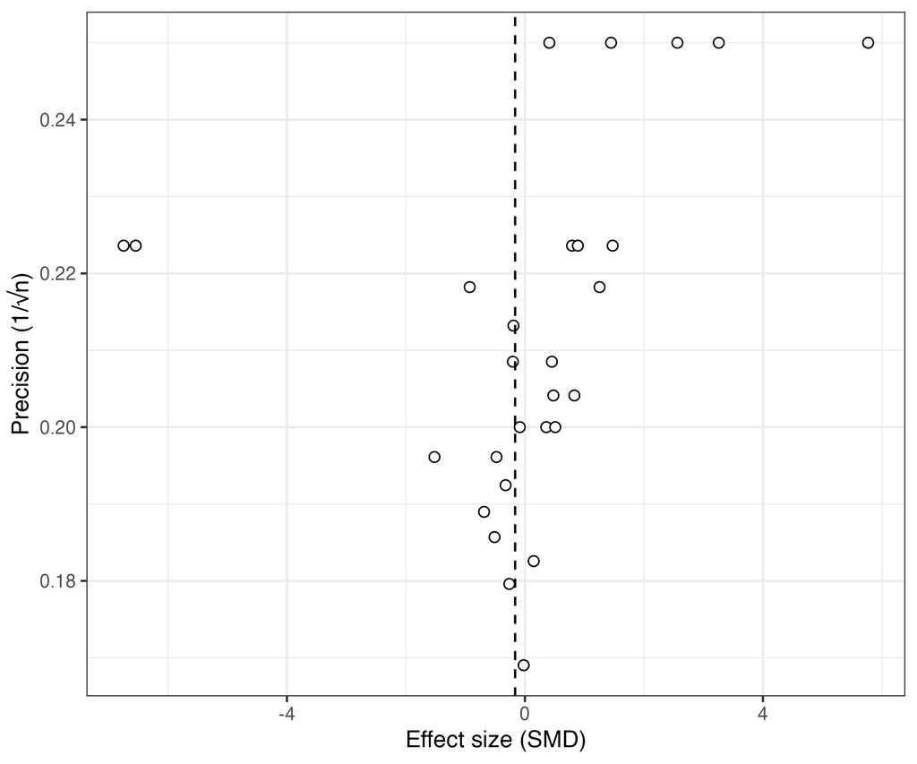

#### Bubble plot (Egger regression)

**Caption.** Bubble plot of effect sizes versus sampling error (SE), with study clustering. **Interpretation.** A visually non-zero slope is consistent with Egger regression evidence for small-study effects; a near-zero slope supports their absence.

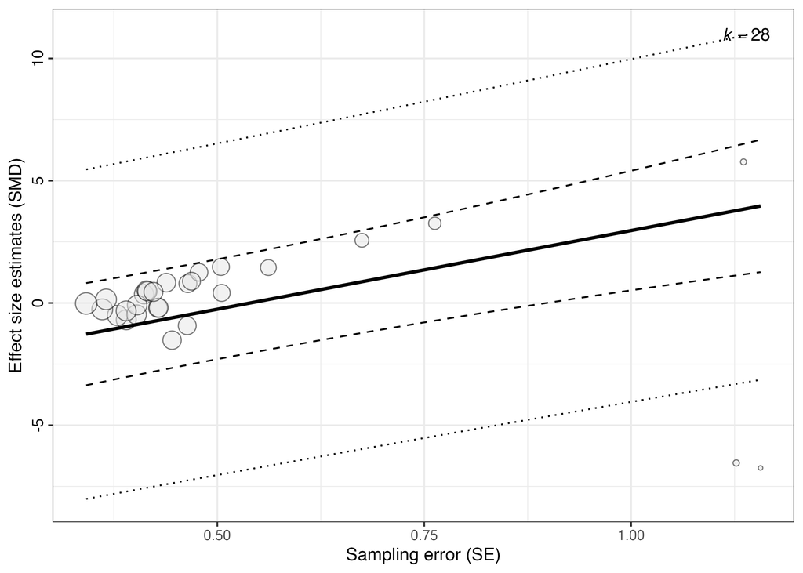

### Sensitivity analyses

#### 5.1 Leave-one-study-out

This analysis repeats the meta-analysis while removing one study at a time to assess influence. **Interpretation.** Large shifts in the pooled estimate indicate influential studies; stability indicates robustness.

| category | left_out | estimate | ci_lb | ci_ub | p_value | sigma2_between | sigma2_within | k | n_studies |
| --- | --- | --- | --- | --- | --- | --- | --- | --- | --- |
| Ethanol | Ariyasiri_2021 | -0.2704 | -1.7138 | 1.1729 | 0.6304 | 0.0000 | 3.7351 | 27 | 5 |
| Ethanol | Baggio_2018 | -0.2603 | -1.7114 | 1.1908 | 0.6446 | 0.0000 | 3.7636 | 24 | 5 |
| Ethanol | Gerlai_2000 | -0.1370 | -1.8244 | 1.5503 | 0.8326 | 0.0000 | 4.5141 | 22 | 5 |
| Ethanol | Gerlai_2008 | -0.3950 | -2.5171 | 1.7271 | 0.6326 | 0.0000 | 6.5243 | 16 | 5 |
| Ethanol | Lutte_2020 | 0.3869 | -0.4503 | 1.2242 | 0.2688 | 0.3028 | 0.0319 | 24 | 5 |
| Ethanol | Stefanello_2021 | -0.3254 | -1.6971 | 1.0464 | 0.5462 | 0.0000 | 3.4767 | 27 | 5 |

#### Sensitivity to within-study correlation (rho)

This analysis varies the assumed within-study correlation among effect sizes. **Interpretation.** Stability of pooled estimates across rho values indicates robustness to assumptions about within-study dependence.

| category | rho | estimate | ci_lb | ci_ub | p_value | sigma2_between | sigma2_within | k | n_studies |
| --- | --- | --- | --- | --- | --- | --- | --- | --- | --- |
| Ethanol | 0.0 | -0.0905 | -1.4988 | 1.3179 | 0.8753 | 0 | 4.3485 | 28 | 6 |
| Ethanol | 0.2 | -0.1108 | -1.4410 | 1.2194 | 0.8389 | 0 | 3.9557 | 28 | 6 |
| Ethanol | 0.4 | -0.1419 | -1.3823 | 1.0984 | 0.7805 | 0 | 3.5297 | 28 | 6 |
| Ethanol | 0.5 | -0.1644 | -1.3572 | 1.0285 | 0.7376 | 0 | 3.3119 | 28 | 6 |
| Ethanol | 0.6 | -0.1947 | -1.3431 | 0.9536 | 0.6811 | 0 | 3.1070 | 28 | 6 |
| Ethanol | 0.8 | -0.3055 | -1.4343 | 0.8234 | 0.5177 | 0 | 2.9298 | 28 | 6 |

## Category: NMDA antagonists

### Overall effect

```
Multivariate Meta-Analysis Model (k = 33; method: REML)

Variance Components:

            estim    sqrt  nlvls  fixed           factor
sigma^2.1  0.7656  0.8750      8     no         study_id
sigma^2.2  0.2015  0.4489     17     no  study_id/exp_id

Test for Heterogeneity:
Q(df = 32) = 94.9634, p-val < .0001

Number of estimates:   33
Number of clusters:    8
Estimates per cluster: 1-18 (mean: 4.12, median: 2)

Model Results:

estimate      se¹    tval¹  df¹    pval¹    ci.lb¹   ci.ub¹
  0.2762  0.3575   0.7724    7   0.4652   -0.5693   1.1216

---
Signif. codes:  0 '***' 0.001 '**' 0.01 '*' 0.05 '.' 0.1 ' ' 1

1) results based on cluster-robust inference (var-cov estimator: CR1,
   approx t-test and confidence interval, df: residual method)
```

| category | estimate | ci_lb | ci_ub | p_value | sigma2_between | sigma2_within | k | n_studies |
| --- | --- | --- | --- | --- | --- | --- | --- | --- |
| NMDA antagonists | 0.2762 | -0.5693 | 1.1216 | 0.4652 | 0.7656 | 0.2015 | 33 | 8 |

### Forest plot

**Caption.** Forest plot of individual effect sizes and the pooled multilevel estimate, including a prediction interval. **Interpretation.** The pooled summary represents the average effect; the prediction interval reflects the expected range of true effects in new studies given heterogeneity.

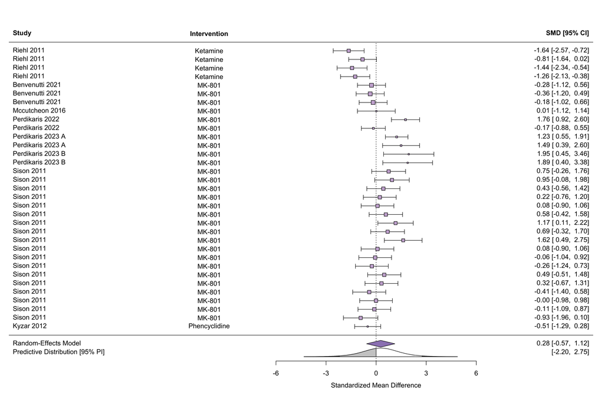

### Heterogeneity and variance decomposition

| category | I2_total | I2_between | I2_within |
| --- | --- | --- | --- |
| NMDA antagonists | 80.562 | 63.774 | 16.788 |

**Interpretation.** I² quantifies the proportion of variability attributable to heterogeneity rather than sampling error, decomposed into between- and within-study components.

### Distribution of effects (orchard plot)

**Caption.** Orchard plot for the multilevel model for this category (PNG saved by the pipeline; colour scheme matches the original script). **Interpretation.** Orchard plots complement forest plots by visualising the distribution of effects with multilevel uncertainty and heterogeneity.

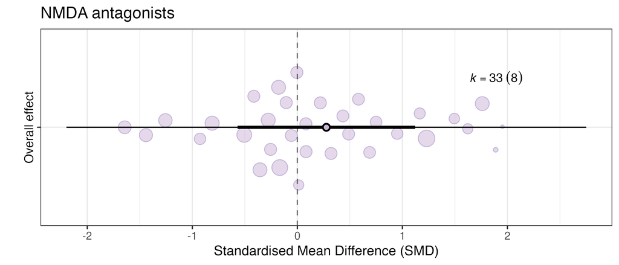

### Small-study effects and publication bias

#### Egger-type regressions

| category | slope_SE | p_SE | slope_SEeff | p_SEeff |
| --- | --- | --- | --- | --- |
| NMDA antagonists | 3.5695 | 0.106 | 3.0207 | 0.3451 |

**Interpretation.** The slope tests whether effect sizes are associated with sampling error (SE) or effective SE. Consistent significance may indicate small-study effects.

#### Funnel plot (Sampling Error)

**Caption.** Funnel plot using Sampling Error. **Interpretation.** Symmetry suggests little evidence of small-study effects; asymmetry suggests potential dissemination bias or related mechanisms.

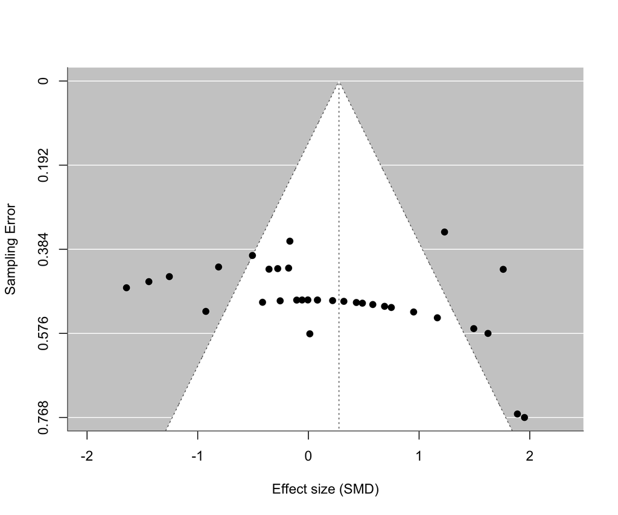

#### Funnel plot (precision = 1/√n)

**Caption.** Funnel plot using 1/√n as an alternative measure of precision. **Interpretation.** Agreement between the two funnel diagnostics strengthens inference about small-study effects.

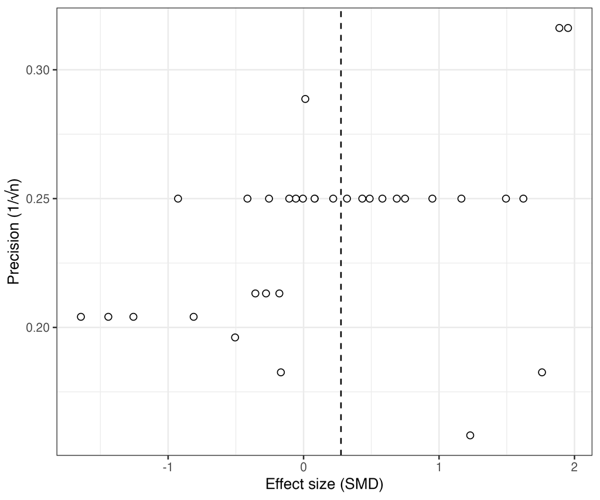

#### Bubble plot (Egger regression)

**Caption.** Bubble plot of effect sizes versus sampling error (SE), with study clustering. **Interpretation.** A visually non-zero slope is consistent with Egger regression evidence for small-study effects; a near-zero slope supports their absence.

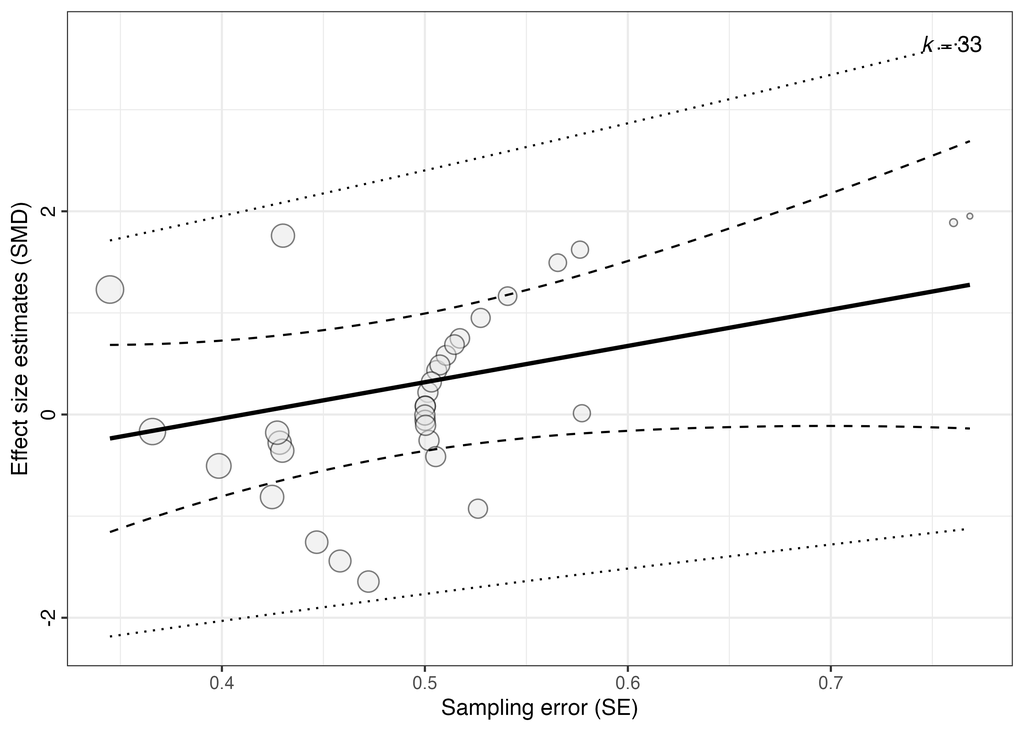

### Sensitivity analyses

#### 5.1 Leave-one-study-out

This analysis repeats the meta-analysis while removing one study at a time to assess influence. **Interpretation.** Large shifts in the pooled estimate indicate influential studies; stability indicates robustness.

| category | left_out | estimate | ci_lb | ci_ub | p_value | sigma2_between | sigma2_within | k | n_studies |
| --- | --- | --- | --- | --- | --- | --- | --- | --- | --- |
| NMDA antagonists | Riehl_2011 | 0.5336 | -0.1842 | 1.2513 | 0.1188 | 0.3145 | 0.2717 | 29 | 7 |
| NMDA antagonists | Benvenutti_2021 | 0.3510 | -0.6325 | 1.3345 | 0.4161 | 0.8775 | 0.2075 | 30 | 7 |
| NMDA antagonists | Mccutcheon_2016 | 0.3074 | -0.6745 | 1.2893 | 0.4727 | 0.8947 | 0.2074 | 32 | 7 |
| NMDA antagonists | Perdikaris_2022 | 0.1860 | -0.7982 | 1.1703 | 0.6601 | 0.9865 | 0.0000 | 31 | 7 |
| NMDA antagonists | Perdikaris_2023_A | 0.1172 | -0.7918 | 1.0261 | 0.7631 | 0.6823 | 0.2360 | 31 | 7 |
| NMDA antagonists | Perdikaris_2023_B | 0.0791 | -0.7417 | 0.9000 | 0.8214 | 0.5463 | 0.2140 | 31 | 7 |
| NMDA antagonists | Sison_2011 | 0.2891 | -0.7684 | 1.3466 | 0.5284 | 0.9195 | 0.3369 | 15 | 7 |
| NMDA antagonists | Kyzar_2012 | 0.3782 | -0.5812 | 1.3376 | 0.3720 | 0.8287 | 0.2060 | 32 | 7 |

#### Sensitivity to within-study correlation (rho)

This analysis varies the assumed within-study correlation among effect sizes. **Interpretation.** Stability of pooled estimates across rho values indicates robustness to assumptions about within-study dependence.

| category | rho | estimate | ci_lb | ci_ub | p_value | sigma2_between | sigma2_within | k | n_studies |
| --- | --- | --- | --- | --- | --- | --- | --- | --- | --- |
| NMDA antagonists | 0.0 | 0.2696 | -0.5822 | 1.1214 | 0.4786 | 0.7729 | 0.2386 | 33 | 8 |
| NMDA antagonists | 0.2 | 0.2717 | -0.5783 | 1.1216 | 0.4744 | 0.7726 | 0.2218 | 33 | 8 |
| NMDA antagonists | 0.4 | 0.2745 | -0.5729 | 1.1218 | 0.4688 | 0.7690 | 0.2080 | 33 | 8 |
| NMDA antagonists | 0.5 | 0.2762 | -0.5693 | 1.1216 | 0.4652 | 0.7656 | 0.2015 | 33 | 8 |
| NMDA antagonists | 0.6 | 0.2782 | -0.5645 | 1.1209 | 0.4606 | 0.7605 | 0.1948 | 33 | 8 |
| NMDA antagonists | 0.8 | 0.2847 | -0.5452 | 1.1146 | 0.4439 | 0.7369 | 0.1747 | 33 | 8 |

## Category: Stress

### Overall effect

```
Multivariate Meta-Analysis Model (k = 29; method: REML)

Variance Components:

            estim    sqrt  nlvls  fixed           factor
sigma^2.1  0.5679  0.7536     15     no         study_id
sigma^2.2  0.0690  0.2626     22     no  study_id/exp_id

Test for Heterogeneity:
Q(df = 28) = 146.9217, p-val < .0001

Number of estimates:   29
Number of clusters:    15
Estimates per cluster: 1-8 (mean: 1.93, median: 2)

Model Results:

estimate      se¹    tval¹  df¹    pval¹    ci.lb¹   ci.ub¹
  0.4395  0.2244   1.9581   14   0.0705   -0.0419   0.9209   .

---
Signif. codes:  0 '***' 0.001 '**' 0.01 '*' 0.05 '.' 0.1 ' ' 1

1) results based on cluster-robust inference (var-cov estimator: CR1,
   approx t-test and confidence interval, df: residual method)
```

| category | estimate | ci_lb | ci_ub | p_value | sigma2_between | sigma2_within | k | n_studies |
| --- | --- | --- | --- | --- | --- | --- | --- | --- |
| Stress | 0.4395 | -0.0419 | 0.9209 | 0.0705 | 0.5679 | 0.069 | 29 | 15 |

### Forest plot

**Caption.** Forest plot of individual effect sizes and the pooled multilevel estimate, including a prediction interval. **Interpretation.** The pooled summary represents the average effect; the prediction interval reflects the expected range of true effects in new studies given heterogeneity.

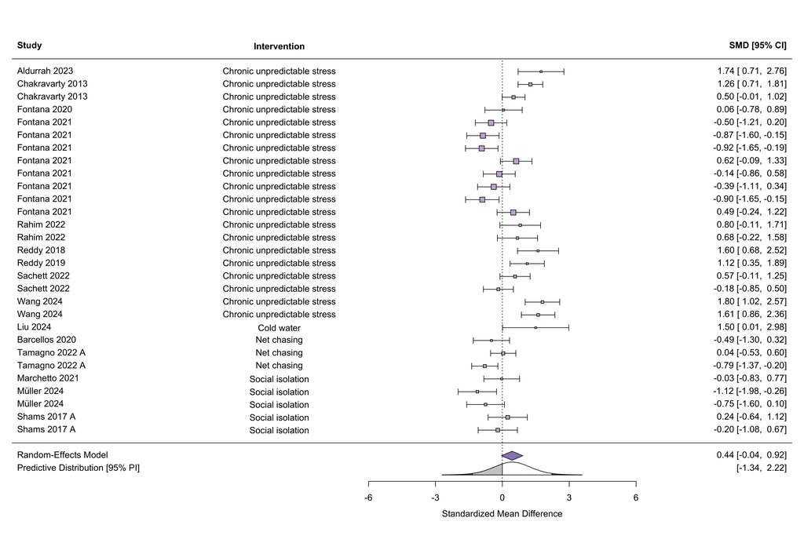

### Heterogeneity and variance decomposition

| category | I2_total | I2_between | I2_within |
| --- | --- | --- | --- |
| Stress | 81.577 | 72.743 | 8.834 |

**Interpretation.** I² quantifies the proportion of variability attributable to heterogeneity rather than sampling error, decomposed into between- and within-study components.

### Distribution of effects (orchard plot)

**Caption.** Orchard plot for the multilevel model for this category (PNG saved by the pipeline; colour scheme matches the original script). **Interpretation.** Orchard plots complement forest plots by visualising the distribution of effects with multilevel uncertainty and heterogeneity.

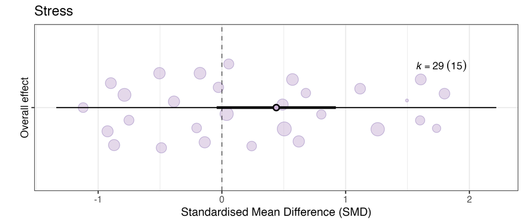

### Small-study effects and publication bias

#### Egger-type regressions

| category | slope_SE | p_SE | slope_SEeff | p_SEeff |
| --- | --- | --- | --- | --- |
| Stress | 1.8298 | 0.4259 | 1.6554 | 0.5577 |

**Interpretation.** The slope tests whether effect sizes are associated with sampling error (SE) or effective SE. Consistent significance may indicate small-study effects.

#### Funnel plot (Sampling Error)

**Caption.** Funnel plot using Sampling Error. **Interpretation.** Symmetry suggests little evidence of small-study effects; asymmetry suggests potential dissemination bias or related mechanisms.

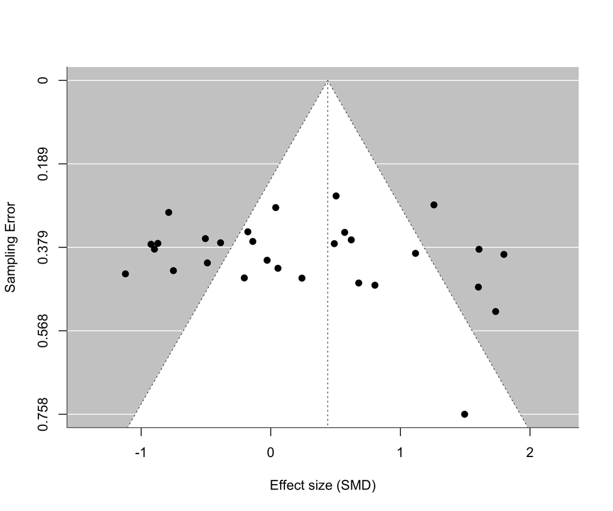

#### Funnel plot (precision = 1/√n)

**Caption.** Funnel plot using 1/√n as an alternative measure of precision. **Interpretation.** Agreement between the two funnel diagnostics strengthens inference about small-study effects.

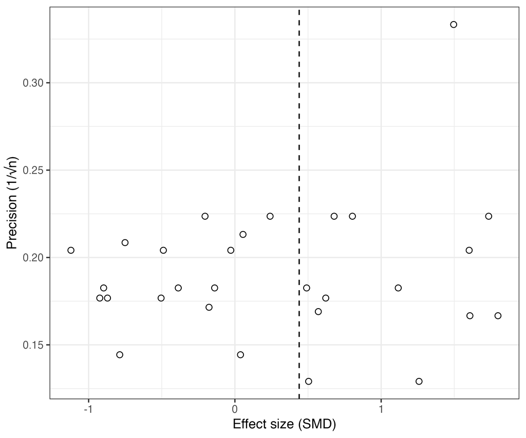

#### Bubble plot (Egger regression)

**Caption.** Bubble plot of effect sizes versus sampling error (SE), with study clustering. **Interpretation.** A visually non-zero slope is consistent with Egger regression evidence for small-study effects; a near-zero slope supports their absence.

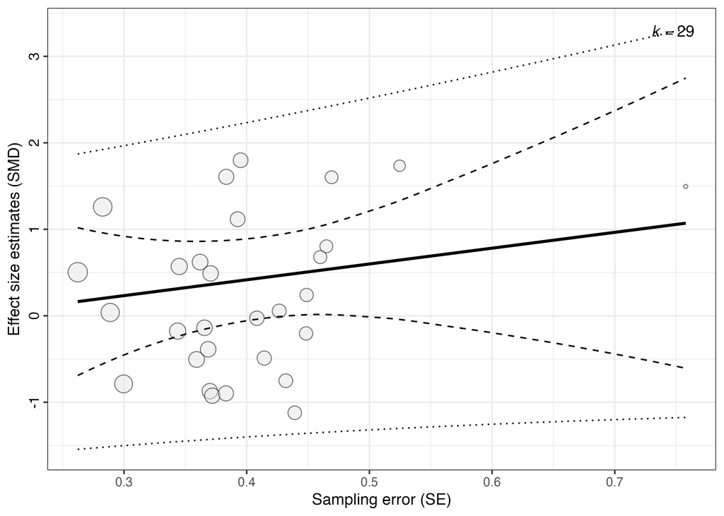

### Sensitivity analyses

#### 5.1 Leave-one-study-out

This analysis repeats the meta-analysis while removing one study at a time to assess influence. **Interpretation.** Large shifts in the pooled estimate indicate influential studies; stability indicates robustness.

| category | left_out | estimate | ci_lb | ci_ub | p_value | sigma2_between | sigma2_within | k | n_studies |
| --- | --- | --- | --- | --- | --- | --- | --- | --- | --- |
| Stress | Aldurrah_2023 | 0.3615 | -0.1202 | 0.8433 | 0.1289 | 0.5197 | 0.0675 | 28 | 14 |
| Stress | Chakravarty_2013 | 0.4080 | -0.1107 | 0.9266 | 0.1130 | 0.6323 | 0.0359 | 27 | 14 |
| Stress | Fontana_2020 | 0.4675 | -0.0484 | 0.9834 | 0.0721 | 0.6131 | 0.0701 | 28 | 14 |
| Stress | Fontana_2021 | 0.5017 | -0.0080 | 1.0114 | 0.0532 | 0.5641 | 0.0935 | 21 | 14 |
| Stress | Rahim_2022 | 0.4188 | -0.1017 | 0.9394 | 0.1058 | 0.6103 | 0.0830 | 27 | 14 |
| Stress | Reddy_2018 | 0.3649 | -0.1212 | 0.8509 | 0.1289 | 0.5290 | 0.0679 | 28 | 14 |
| Stress | Reddy_2019 | 0.3943 | -0.1126 | 0.9011 | 0.1167 | 0.5843 | 0.0698 | 28 | 14 |
| Stress | Sachett_2022 | 0.4634 | -0.0609 | 0.9876 | 0.0785 | 0.6357 | 0.0579 | 27 | 14 |
| Stress | Wang_2024 | 0.3253 | -0.1359 | 0.7865 | 0.1515 | 0.4319 | 0.0913 | 27 | 14 |
| Stress | Liu_2024 | 0.3935 | -0.1015 | 0.8886 | 0.1096 | 0.5666 | 0.0692 | 28 | 14 |
| Stress | Barcellos_2020 | 0.5013 | 0.0008 | 1.0018 | 0.0497 | 0.5679 | 0.0682 | 28 | 14 |
| Stress | Tamagno_2022_A | 0.5083 | 0.0045 | 1.0120 | 0.0483 | 0.5885 | 0.0354 | 27 | 14 |
| Stress | Marchetto_2021 | 0.4734 | -0.0415 | 0.9883 | 0.0685 | 0.6092 | 0.0699 | 28 | 14 |
| Stress | Müller_2024 | 0.5397 | 0.0755 | 1.0039 | 0.0260 | 0.4476 | 0.0828 | 27 | 14 |
| Stress | Shams_2017_A | 0.4711 | -0.0452 | 0.9873 | 0.0704 | 0.6123 | 0.0700 | 27 | 14 |

#### Sensitivity to within-study correlation (rho)

This analysis varies the assumed within-study correlation among effect sizes. **Interpretation.** Stability of pooled estimates across rho values indicates robustness to assumptions about within-study dependence.

| category | rho | estimate | ci_lb | ci_ub | p_value | sigma2_between | sigma2_within | k | n_studies |
| --- | --- | --- | --- | --- | --- | --- | --- | --- | --- |
| Stress | 0.0 | 0.4341 | -0.0462 | 0.9145 | 0.0730 | 0.5764 | 0.0603 | 29 | 15 |
| Stress | 0.2 | 0.4361 | -0.0449 | 0.9170 | 0.0722 | 0.5730 | 0.0645 | 29 | 15 |
| Stress | 0.4 | 0.4382 | -0.0431 | 0.9196 | 0.0711 | 0.5697 | 0.0676 | 29 | 15 |
| Stress | 0.5 | 0.4395 | -0.0419 | 0.9209 | 0.0705 | 0.5679 | 0.0690 | 29 | 15 |
| Stress | 0.6 | 0.4410 | -0.0403 | 0.9223 | 0.0696 | 0.5657 | 0.0701 | 29 | 15 |
| Stress | 0.8 | 0.4463 | -0.0336 | 0.9261 | 0.0659 | 0.5578 | 0.0722 | 29 | 15 |

# Combined orchard plots across all categories

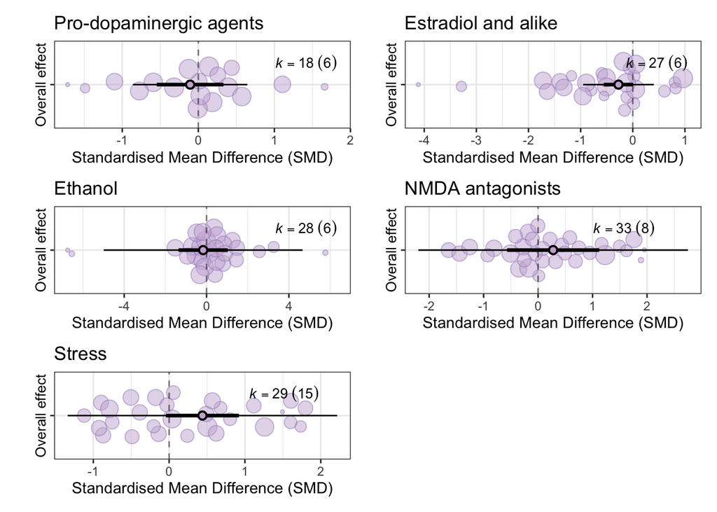

**Caption.** Combined orchard plots for all categories.  
**Interpretation.** This panel supports direct comparison of pooled effects and uncertainty across categories.

# Miscellaneous studies

[figure not shown]

**Caption.** Forest plot for miscellaneous studies (descriptive fixed-effect display).  
**Interpretation.** Miscellaneous studies are shown descriptively and not pooled into the main multilevel models due to conceptual heterogeneity.

# Computational environment

R version: R version 4.5.1 (2025-06-13) Platform: Darwin / 24.5.0 / arm64 Render date: 2025-12-14

R version 4.5.1 (2025-06-13) Platform: aarch64-apple-darwin20 Running under: macOS Sequoia 15.5

Matrix products: default BLAS: /Library/Frameworks/R.framework/Versions/4.5-arm64/Resources/lib/libRblas.0.dylib LAPACK: /Library/Frameworks/R.framework/Versions/4.5-arm64/Resources/lib/libRlapack.dylib; LAPACK version 3.12.1

locale: [1] en_US.UTF-8/en_US.UTF-8/en_US.UTF-8/C/en_US.UTF-8/en_US.UTF-8

time zone: America/Sao_Paulo tzcode source: internal

attached base packages: [1] stats graphics grDevices utils datasets methods base

other attached packages: [1] patchwork_1.3.2 orchaRd_2.1.3 clubSandwich_0.6.1 metafor_4.8-0 numDeriv_2016.8-1.1 [6] metadat_1.4-0 Matrix_1.7-3 lubridate_1.9.4 forcats_1.0.0 stringr_1.5.2  
[11] dplyr_1.1.4 purrr_1.1.0 readr_2.1.6 tidyr_1.3.1 tibble_3.3.0  
[16] ggplot2_4.0.1 tidyverse_2.0.0

loaded via a namespace (and not attached): [1] beeswarm_0.4.0 gtable_0.3.6 xfun_0.53 bslib_0.9.0 lattice_0.22-7 mathjaxr_1.8-0  
[7] tzdb_0.5.0 vctrs_0.6.5 tools_4.5.1 generics_0.1.4 parallel_4.5.1 sandwich_3.1-1  
[13] pkgconfig_2.0.3 RColorBrewer_1.1-3 S7_0.2.0 lifecycle_1.0.4 compiler_4.5.1 farver_2.1.2  
[19] textshaping_1.0.4 codetools_0.2-20 vipor_0.4.7 htmltools_0.5.8.1 sass_0.4.10 yaml_2.3.10  
[25] pillar_1.11.1 crayon_1.5.3 jquerylib_0.1.4 MASS_7.3-65 cachem_1.1.0 multcomp_1.4-28  
[31] nlme_3.1-168 tidyselect_1.2.1 digest_0.6.37 mvtnorm_1.3-3 stringi_1.8.7 labeling_0.4.3  
[37] splines_4.5.1 latex2exp_0.9.6 fastmap_1.2.0 grid_4.5.1 cli_3.6.5 magrittr_2.0.4  
[43] survival_3.8-3 TH.data_1.1-4 withr_3.0.2 scales_1.4.0 bit64_4.6.0-1 ggbeeswarm_0.7.2  
[49] timechange_0.3.0 estimability_1.5.1 rmarkdown_2.29 emmeans_1.11.2-8 bit_4.6.0 png_0.1-8  
[55] ragg_1.5.0 zoo_1.8-14 hms_1.1.3 coda_0.19-4.1 evaluate_1.0.5 knitr_1.50  
[61] mgcv_1.9-3 rlang_1.1.7 xtable_1.8-4 glue_1.8.0 rstudioapi_0.17.1 vroom_1.6.6  
[67] jsonlite_2.0.0 R6_2.6.1 systemfonts_1.3.1